← Probabilistic Machine Learning

# The $\mathbf{A} \mathbf{B} \mathbf{A}^T$ Pattern: Transforming Covariance

This pattern appears **everywhere** in statistics and machine learning:

$$\mathbf{A} \mathbf{B} \mathbf{A}^T$$

It answers the fundamental question: *"If I transform data by $\mathbf{A}$, how does its covariance change?"*

### The Core Theorem

If $\mathbf{x}$ has covariance $\mathbf{\Sigma}$ and we compute $\mathbf{y} = \mathbf{A}\mathbf{x}$, then:

$$\text{Cov}(\mathbf{y}) = \mathbf{A} \, \text{Cov}(\mathbf{x}) \, \mathbf{A}^T = \mathbf{A} \mathbf{\Sigma} \mathbf{A}^T$$

### Where It Appears

- **Kalman filter**: Prediction step $\mathbf{P}_{pred} = \mathbf{F} \mathbf{P} \mathbf{F}^T + \mathbf{Q}$
- **Factor analysis**: $\mathbf{\Sigma} = \mathbf{\Lambda} \mathbf{\Psi} \mathbf{\Lambda}^T + \text{noise}$
- **Sensor fusion**: Fused covariance = $\mathbf{A} \mathbf{\Sigma}_{sensors} \mathbf{A}^T$
- **Bayesian linear regression**: Posterior covariance transformation

```python
import numpy as np
import matplotlib.pyplot as plt
from matplotlib.patches import Ellipse

np.random.seed(42)
plt.rcParams['figure.figsize'] = (12, 6)
plt.rcParams['font.size'] = 11
```

## 1. Why This Pattern?

Let's derive it from first principles.

**Given**: $\mathbf{x}$ is a random vector with $\text{Cov}(\mathbf{x}) = E[(\mathbf{x} - \mu)(\mathbf{x} - \mu)^T] = \mathbf{\Sigma}$

**Transform**: $\mathbf{y} = \mathbf{A}\mathbf{x}$

**Question**: What is $\text{Cov}(\mathbf{y})$?

\begin{align} \text{Cov}(\mathbf{y}) &= E[(\mathbf{y} - \mu_y)(\mathbf{y} - \mu_y)^T] \\ &= E[(\mathbf{A}\mathbf{x} - \mathbf{A}\mu_x)(\mathbf{A}\mathbf{x} - \mathbf{A}\mu_x)^T] \\ &= E[\mathbf{A}(\mathbf{x} - \mu_x)(\mathbf{x} - \mu_x)^T\mathbf{A}^T] \\ &= \mathbf{A} \, E[(\mathbf{x} - \mu_x)(\mathbf{x} - \mu_x)^T] \, \mathbf{A}^T \\ &= \mathbf{A} \mathbf{\Sigma} \mathbf{A}^T \end{align}

```python
# Verify with simulation
n_samples = 10000

# Original distribution
mu = np.array([0, 0])
Sigma = np.array([[1.0, 0.5],
                  [0.5, 1.0]])

# Transformation matrix
A = np.array([[2, 1],
              [0, 1.5]])

# Generate samples
X = np.random.multivariate_normal(mu, Sigma, n_samples)

# Transform
Y = (A @ X.T).T

# Compare theoretical vs empirical covariance
Sigma_Y_theoretical = A @ Sigma @ A.T
Sigma_Y_empirical = np.cov(Y.T)

print("Covariance Transformation: Σ_y = A Σ_x A.T")
print("="*50)
print(f"\nOriginal Σ_x:")
print(Sigma)
print(f"\nTransformation A:")
print(A)
print(f"\nTheoretical Σ_y = A Σ_x A.T:")
print(Sigma_Y_theoretical)
print(f"\nEmpirical Σ_y (from {n_samples:,} samples):")
print(Sigma_Y_empirical.round(3))
print(f"\nClose match: {np.allclose(Sigma_Y_theoretical, Sigma_Y_empirical, rtol=0.05)}")
```

```
Covariance Transformation: Σ_y = A Σ_x A.T
==================================================

Original Σ_x:
[[1.  0.5]
 [0.5 1. ]]

Transformation A:
[[2.  1. ]
 [0.  1.5]]

Theoretical Σ_y = A Σ_x A.T:
[[7.   3.  ]
 [3.   2.25]]

Empirical Σ_y (from 10,000 samples):
[[7.14  3.085]
 [3.085 2.287]]

Close match: True
```

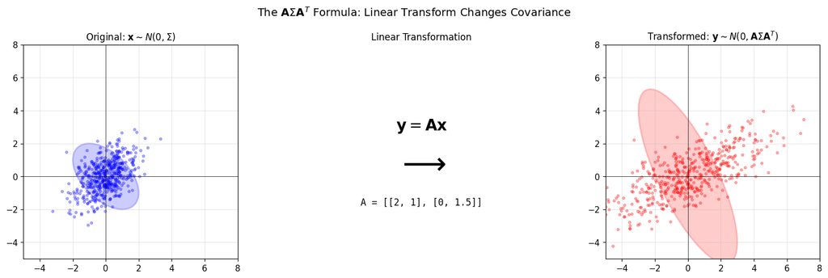

```python
def plot_covariance_ellipse(ax, mean, cov, n_std=2, **kwargs):
    """Plot a covariance ellipse."""
    eigenvalues, eigenvectors = np.linalg.eigh(cov)
    angle = np.degrees(np.arctan2(eigenvectors[1, 1], eigenvectors[0, 1]))
    width, height = 2 * n_std * np.sqrt(eigenvalues)
    ellipse = Ellipse(mean, width, height, angle=angle, **kwargs)
    ax.add_patch(ellipse)
    return ellipse

# Visualize the transformation
fig, axes = plt.subplots(1, 3, figsize=(16, 5))

# Original
ax1 = axes[0]
ax1.scatter(X[:500, 0], X[:500, 1], alpha=0.3, s=10, c='blue')
plot_covariance_ellipse(ax1, mu, Sigma, n_std=2, facecolor='blue', alpha=0.2, edgecolor='blue', linewidth=2)
ax1.set_xlim(-5, 8)
ax1.set_ylim(-5, 8)
ax1.set_aspect('equal')
ax1.set_title('Original: $\\mathbf{x} \\sim N(0, \\Sigma)$', fontsize=12)
ax1.grid(True, alpha=0.3)
ax1.axhline(y=0, color='black', linewidth=0.5)
ax1.axvline(x=0, color='black', linewidth=0.5)

# Arrow showing transformation
ax2 = axes[1]
ax2.text(0.5, 0.6, '$\\mathbf{y} = \\mathbf{A}\\mathbf{x}$', fontsize=20, ha='center', transform=ax2.transAxes)
ax2.text(0.5, 0.4, '$\\longrightarrow$', fontsize=40, ha='center', transform=ax2.transAxes)
ax2.text(0.5, 0.25, f'A = [[2, 1], [0, 1.5]]', fontsize=12, ha='center', transform=ax2.transAxes, family='monospace')
ax2.axis('off')
ax2.set_title('Linear Transformation', fontsize=12)

# Transformed
ax3 = axes[2]
ax3.scatter(Y[:500, 0], Y[:500, 1], alpha=0.3, s=10, c='red')
plot_covariance_ellipse(ax3, np.zeros(2), Sigma_Y_theoretical, n_std=2,
                        facecolor='red', alpha=0.2, edgecolor='red', linewidth=2)
ax3.set_xlim(-5, 8)
ax3.set_ylim(-5, 8)
ax3.set_aspect('equal')
ax3.set_title('Transformed: $\\mathbf{y} \\sim N(0, \\mathbf{A}\\Sigma\\mathbf{A}^T)$', fontsize=12)
ax3.grid(True, alpha=0.3)
ax3.axhline(y=0, color='black', linewidth=0.5)
ax3.axvline(x=0, color='black', linewidth=0.5)

plt.suptitle('The $\\mathbf{A}\\Sigma\\mathbf{A}^T$ Formula: Linear Transform Changes Covariance', fontsize=14)
plt.tight_layout()
plt.show()
```

## Real-World Scenario: Sensor Fusion for Robot Localization

**Scenario**: A robot uses 3 sensors to estimate its position. Each sensor has different accuracy. We want to **combine** them optimally.

The fusion weights matrix $\mathbf{A}$ determines how to combine measurements, and $\mathbf{A} \mathbf{\Sigma}_{sensors} \mathbf{A}^T$ gives the uncertainty of the fused estimate.

```python
# Sensor uncertainties (variance in position estimate)
# LiDAR: accurate, GPS: moderate, Wheel odometry: poor
var_lidar = 0.04    # σ = 0.2 meters
var_gps = 0.25      # σ = 0.5 meters
var_odom = 0.64     # σ = 0.8 meters

# Combined sensor covariance (assuming independence)
Sigma_sensors = np.diag([var_lidar, var_gps, var_odom])

print("Sensor Covariances (diagonal = independent sensors)")
print("="*50)
sensors = ['LiDAR', 'GPS', 'Odometry']
for name, var in zip(sensors, [var_lidar, var_gps, var_odom]):
    print(f"  {name:12}: σ² = {var:.2f}  (σ = {np.sqrt(var):.2f} m)")
```

```
Sensor Covariances (diagonal = independent sensors)
==================================================
  LiDAR       : σ² = 0.04  (σ = 0.20 m)
  GPS         : σ² = 0.25  (σ = 0.50 m)
  Odometry    : σ² = 0.64  (σ = 0.80 m)
```

```python
# Fusion strategy: weighted average based on inverse variance
# More accurate sensors get higher weight
variances = np.array([var_lidar, var_gps, var_odom])
weights = (1/variances) / np.sum(1/variances)  # Normalize to sum to 1

# Fusion matrix A: (1x3) - combines 3 sensor readings into 1 estimate
A = weights.reshape(1, -1)

print("\nOptimal Fusion Weights (inverse variance weighting)")
print("="*50)
for name, w in zip(sensors, weights):
    print(f"  {name:12}: weight = {w:.3f}")
print(f"\nFusion matrix A = {A.round(3)}")
```

```
Optimal Fusion Weights (inverse variance weighting)
==================================================
  LiDAR       : weight = 0.818
  GPS         : weight = 0.131
  Odometry    : weight = 0.051

Fusion matrix A = [[0.818 0.131 0.051]]
```

```python
# THE KEY FORMULA: Fused variance = A @ Σ_sensors @ A.T
Sigma_fused = A @ Sigma_sensors @ A.T

print("\nFused Uncertainty: Σ_fused = A @ Σ_sensors @ A.T")
print("="*50)
print(f"\nΣ_fused = {Sigma_fused[0,0]:.4f}")
print(f"σ_fused = {np.sqrt(Sigma_fused[0,0]):.3f} meters")
print(f"\nComparison:")
print(f"  Best single sensor (LiDAR): σ = {np.sqrt(var_lidar):.3f} m")
print(f"  Fused estimate:             σ = {np.sqrt(Sigma_fused[0,0]):.3f} m  ← BETTER!")
print(f"\nImprovement: {(1 - np.sqrt(Sigma_fused[0,0])/np.sqrt(var_lidar))*100:.1f}% more accurate than best sensor alone")
```

```
Fused Uncertainty: Σ_fused = A @ Σ_sensors @ A.T
==================================================

Σ_fused = 0.0327
σ_fused = 0.181 meters

Comparison:
  Best single sensor (LiDAR): σ = 0.200 m
  Fused estimate:             σ = 0.181 m  ← BETTER!

Improvement: 9.6% more accurate than best sensor alone
```

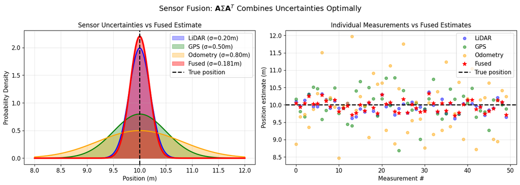

```python
# Visualize the fusion
fig, axes = plt.subplots(1, 2, figsize=(14, 5))

# True position
true_pos = 10.0  # meters

# Simulate measurements
np.random.seed(42)
n_measurements = 50
measurements = np.column_stack([
    np.random.normal(true_pos, np.sqrt(var_lidar), n_measurements),
    np.random.normal(true_pos, np.sqrt(var_gps), n_measurements),
    np.random.normal(true_pos, np.sqrt(var_odom), n_measurements)
])

# Fuse each measurement set
fused = measurements @ A.T

# Left: Individual sensor distributions
ax1 = axes[0]
x_range = np.linspace(8, 12, 200)
for i, (name, var, color) in enumerate(zip(sensors, variances, ['blue', 'green', 'orange'])):
    pdf = 1/np.sqrt(2*np.pi*var) * np.exp(-(x_range - true_pos)**2 / (2*var))
    ax1.fill_between(x_range, pdf, alpha=0.3, color=color, label=f'{name} (σ={np.sqrt(var):.2f}m)')
    ax1.plot(x_range, pdf, color=color, linewidth=2)

# Fused distribution
pdf_fused = 1/np.sqrt(2*np.pi*Sigma_fused[0,0]) * np.exp(-(x_range - true_pos)**2 / (2*Sigma_fused[0,0]))
ax1.fill_between(x_range, pdf_fused, alpha=0.4, color='red', label=f'Fused (σ={np.sqrt(Sigma_fused[0,0]):.3f}m)')
ax1.plot(x_range, pdf_fused, 'r-', linewidth=3)

ax1.axvline(x=true_pos, color='black', linestyle='--', linewidth=2, label='True position')
ax1.set_xlabel('Position (m)')
ax1.set_ylabel('Probability Density')
ax1.set_title('Sensor Uncertainties vs Fused Estimate', fontsize=12)
ax1.legend()
ax1.grid(True, alpha=0.3)

# Right: Simulated measurements
ax2 = axes[1]
for i, (name, color) in enumerate(zip(sensors, ['blue', 'green', 'orange'])):
    ax2.scatter(range(n_measurements), measurements[:, i], alpha=0.5, s=30, c=color, label=name)
ax2.scatter(range(n_measurements), fused, c='red', s=60, marker='*', label='Fused', zorder=5)
ax2.axhline(y=true_pos, color='black', linestyle='--', linewidth=2, label='True position')
ax2.set_xlabel('Measurement #')
ax2.set_ylabel('Position estimate (m)')
ax2.set_title('Individual Measurements vs Fused Estimates', fontsize=12)
ax2.legend(loc='upper right')
ax2.grid(True, alpha=0.3)

plt.suptitle('Sensor Fusion: $\\mathbf{A}\\Sigma\\mathbf{A}^T$ Combines Uncertainties Optimally', fontsize=14)
plt.tight_layout()
plt.show()
```